# Statistics 651 Building Models

Winter 2026

## Objectives

1. Write a statistical model in generative form
2. Simulate from a generative model
3. Perform a Bayesian analysis on one parameter in a conjugate setting

## Resources

- BDA3: Ch 2.1-2.3
- BIDA: Ch 4.6-4.7
- Hoff: Ch 4 (Monte Carlo)

# Statistical models

## Parametric models

**Definition**

Let $\boldsymbol{x} = (\boldsymbol{x}_1, \ldots, \boldsymbol{x}_n)$ belong to a sample space, $\mathcal{X}^n = \mathcal{X} \times \cdots \times \mathcal{X}$ with $\boldsymbol{x}_i = (x_{i,1}, \ldots, x_{i,K}) \in \mathcal{X}$, and associated Borel field $\mathcal{B}(\mathcal{X}^n)$.

Let $F^n_\boldsymbol{\theta}$ denote a probability distribution on $\mathcal{X}^n$, $\mathcal{B}(\mathcal{X}^n)$ indexed by finite-dimensional parameter $\boldsymbol{\theta} \in \boldsymbol{\Theta}$.

A **parametric statistical model** is the collection

$$\mathbb{M} = \{ \mathbb{P}_\boldsymbol{\theta}(A) : \boldsymbol{\theta} \in \boldsymbol{\Theta} \} \, ,$$
where $\mathbb{P}_\boldsymbol{\theta}(A) = \int_A F_\boldsymbol{\theta}^n (\mbox{d}\boldsymbol{x}_1, \mbox{d}\boldsymbol{x}_2, \ldots, \mbox{d}\boldsymbol{x}_n)$ for any $A \in \mathcal{B}(\mathcal{X}^n)$.

A model is **identifiable** if distinct values of $\boldsymbol{\theta}$ result in distinct distributions $F^n_\boldsymbol{\theta}$.

Informally, a **nonparemetric statistical model** is one in which $\boldsymbol{\theta}$ is not finite-dimensional.

See [Wikipedia: Statistical Model](https://en.wikipedia.org/wiki/Statistical_model) and [McCullagh (2002)](https://www.stat.uchicago.edu/~pmcc/pubs/AOS023.pdf).

## Parametric models

**Examples**

Identify $\mathcal{X}$ (and $\mathcal{X}^n$), $\boldsymbol{\Theta}$, and $F_\boldsymbol{\theta}$ (and $F_\boldsymbol{\theta}^n$) for each of the following models.

1. $x \sim \mbox{Binomial}(n, \phi)$.
2. $x_i \overset{\text{iid}}{\sim} \mbox{Normal}(\mu, 1)$ for $i = 1, \ldots, n$.
3. $y_i \overset{\text{ind}}{\sim} \mbox{Normal}(\beta_0 + \beta_1 x_i, \ \sigma^2)$ for $i = 1, \ldots, n$.

## Likelihood

**Definition**

The density (or mass) function associated with $F_\boldsymbol{\theta}^n$, when viewed as a function of $\boldsymbol{\theta}$, is called the **likelihood function**, written as

$$\mathcal{L}(\boldsymbol{\theta}; \boldsymbol{x}) := f(\boldsymbol{x} \mid \boldsymbol{\theta}) \, .$$
The natural log of the likelihood is written as

$$\ell(\boldsymbol{\theta}; \boldsymbol{x}) := \log(\mathcal{L}(\boldsymbol{\theta}; \boldsymbol{x})) \, .$$

Many Bayesians believe in the “Likelihood Principle,” which states that all inferential evidence provided by the data should be encoded in the likelihood.

Likelihood-based inference is due to R. A. Fisher (see [Aldrich, 1997](https://projecteuclid.org/journals/statistical-science/volume-12/issue-3/RA-Fisher-and-the-making-of-maximum-likelihood-1912-1922/10.1214/ss/1030037906.full)).

## Bayesian model

**Definition**

A parametric **Bayesian statistical model** is then $\mathbb{M} = \{ \mathbb{P}_\boldsymbol{\theta}(A) : \boldsymbol{\theta} \in \boldsymbol{\Theta} \}$ together with $\Pi$, a probability distribution on $\boldsymbol{\theta}$.

The distribution $\Pi$ encodes information (or beliefs) about $\boldsymbol{\theta}$, *external to the data*, and is called the **prior distribution**.

Taken together, $F_\boldsymbol{\theta}^n$ and $\Pi$ define a *joint probability* distribution for the data and the parameters.

In Bayesian models, assumptions are explicitly encoded in the joint model.

## Generative view

**Chain rule of probability**

For events

$$\mathbb{P}(A_1 \cap A_2 \cap \cdots \cap A_n) = \mathbb{P}(A_1) \mathbb{P}(A_2 \mid A_1) \cdots \mathbb{P}(A_n \mid A_1, \ldots, A_{n-1})$$

For distributions

$$f(x_1, x_2, \ldots, x_n) = f(x_1) f(x_2 \mid x_1) \cdots f(x_n \mid x_1, \ldots, x_{n-1})$$
For (hierarchical) models

$$p(\psi, \theta, \boldsymbol{x}) = p(\psi) p(\theta \mid \psi) p(\boldsymbol{x} \mid \theta, \psi )$$

Note: For tractability and simplicity, it is common to assume **conditional independence** between levels of hierarchy, i.e., $p(\boldsymbol{x} \mid \theta, \psi ) = p(\boldsymbol{x} \mid \theta )$.

## Simulation

Step 1: Simulate $\psi$ from its prior.

Step 2: Simulate $\theta \mid \psi$ from its conditional prior.

Step 3: Simulate $\boldsymbol{x} \mid \theta, \psi$ from the sampling model (likelihood).

The sample $(\psi, \theta, \boldsymbol{x})$ is then a draw from the joint distribution $p(\psi, \theta, \boldsymbol{x})$.

## Generative model

**Dating example**

Recall the “state” is your date’s reciprocal interest in continuing to date, which is unknown to you.  
Let $\theta \in [0,1]$ with $0$ being total disinterest.

We collect “data” to try and infer their interest. Let $x_i \in \{0, 1\}$ for $i = 1, \ldots, n$ denote your date’s response (1 is positive) to your $i$th “effort” to guage their interest.

For simplicity, assume $x_i \mid \theta \overset{\text{iid}}{\sim} \mbox{Bernoulli}(\theta)$.

What is a reasonable prior for $\theta$?

Simulate from the joint distribution for $(\theta, \boldsymbol{x})$.

## Generative model

**Dating example continued**

We have $\theta \sim \mbox{Beta}(a, b)$ and $x_i \mid \theta \overset{\text{iid}}{\sim} \mbox{Bernoulli}(\theta)$ for $i = 1, \ldots, n$.

Write the joint distribution for $(\theta, \boldsymbol{x})$.

Simulate from the joint distribution for $(\theta, \boldsymbol{x})$.

## Prior predictive distributions

**Definition**

The denominator in Bayes’ theorem

$$\mathbb{P}(\theta \in A \mid \boldsymbol{x}) = \frac{ \int_A f(\boldsymbol{x} \mid \theta) \, \Pi(\mbox{d}\theta)}{ \int_\Theta f(\boldsymbol{x} \mid \theta) \, \Pi(\mbox{d}\theta)} \, ,$$
i.e., $\int_\Theta f(\boldsymbol{x} \mid \theta) \, \Pi(\mbox{d}\theta) =: f(\boldsymbol{x})$, is the marginal distribution of the data, under the chosen model. It is sometimes called the **evidence**.

Similarly, we can define **prior predictive** distribution for $\tilde{x}$:

$$\int_\Theta f(\tilde{x} \mid \theta) \, \Pi(\mbox{d}\theta) \, .$$

- How would you simulate from the prior predictive distribution?
- The prior predictive distribution can be used to assess how realistic a prior is.

## Prior predictive distributions

**Dating example continued**

We have $\theta \sim \mbox{Beta}(a, b)$ and $x_i \mid \theta \overset{\text{iid}}{\sim} \mbox{Bernoulli}(\theta)$ for $i = 1, \ldots, n$.

Find the prior predictive distribution for the outcome of a single effort $\tilde{x}$.

Compare this to the marginal distribution of one of the $x_i$ from the simulation.

# Posterior inference

## Posterior distribution

**Shorthand notation**

We often use
$$p(\theta \mid x) = \frac{p(x, \theta)}{\int p(x, \theta) \, \mbox{d}\theta} = \frac{p(x \mid \theta) \, p(\theta)}{\int p(x \mid \theta) \, p(\theta) \, \mbox{d}\theta}$$
to denote the posterior and contributing densities, whether for discrete or continuous variables, univariate or multivariate.

## Posterior distribution

**Dating example continued**

Suppose that from $n = 6$ efforts, we have: $x_1 = 1, \ x_2 = 1, \ x_3 = 0, \ x_4 = 1, \, x_5 = 0, \ x_6 = 1$.

Find the posterior distribution of $\theta$.

## Posterior distribution

**Dating example continued**

Find the posterior distribution among the samples of $(\theta, \boldsymbol{x})$ by conditioning on $\sum_{i=1}^6 x_i = 4$.

## Posterior distribution

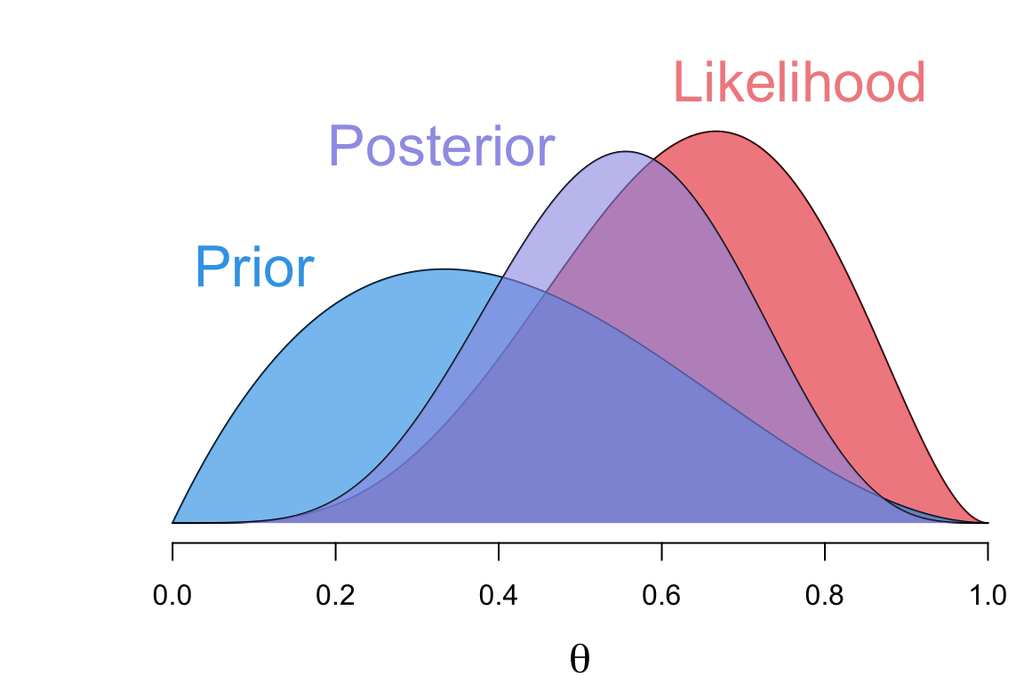

```r
a <- 2
b <- 3
n <- 6
y <- 4

col_data <- rgb(0.9, 0.2, 0.2, 0.6)
col_pri <- rgb(0.1, 0.6, 0.9, 0.6)
col_post <- rgb(0.6, 0.6, 0.9, 0.6)

col_pri_txt <- rgb(0.1, 0.6, 0.9, 0.9)
col_post_txt <- rgb(0.6, 0.6, 0.9, 0.95)

lik <- function(x) x^y * (1.0 - x)^(n - y) * 1.25e2 # scale up for visual

par(mar = c(4,4,0,0) + 0.1)
curve(lik(x), from = 0, to = 1, n = 1000, ylim = c(0, 3.5),
      xlab = expression(theta), ylab = "", cex.lab = 1.5, axes = FALSE)
axis(side = 1)
x_coords <- c(0, seq(0, 1, by = 0.01), 1)
y_coords <- c(0, sapply(seq(0, 1, by = 0.01), lik), 0)
polygon(x_coords, y_coords, col = col_data, border = "NA")

curve(dbeta(x, a, b), from = 0, to = 1, n = 1000, add = TRUE)
y_coords <- c(0, dbeta(seq(0, 1, by = 0.01), a, b), 0)
polygon(x_coords, y_coords, col = col_pri, border = "NA")

curve(dbeta(x, a + y, b + n - y), from = 0, to = 1, n = 1000, add = TRUE)
y_coords <- c(0, dbeta(seq(0, 1, by = 0.01), a + y, b + n - y), 0)
polygon(x_coords, y_coords, col = col_post, border = "NA")

text(0.1, 1.8, expression("Prior"), col = col_pri_txt, cex = 2)
text(0.33, 2.65, expression("Posterior"), col = col_post_txt, cex = 2)
text(0.77, 3.1, expression("Likelihood"), col = col_data, cex = 2)
```

## Posterior summary

The posterior distribution characterizes your updated beliefs about $\boldsymbol{\theta}$ given the data.

Summaries of $\Pi(\boldsymbol{\theta} \mid \boldsymbol{x})$ often include

- Posterior mean, mode
- Posterior quantiles
- Credible intervals
- Predictive distributions

## Posterior summary

**Dating example**

Find the posterior mean ($\int \theta \, p(\theta \mid \boldsymbol{x}) \, \mbox{d}\theta$), median, and mode in the dating example.

Recall $n = 6$ and $\sum_i x_i = 4$.

## Bayes (point) estimators

The posterior mean can often be written as a weighted combination of a classical estimator and a prior point estimator.

**Dating example**

Rewrite the posterior mean in the dating example.

## Posterior (credible) intervals

**Definition**

Any interval that covers $\gamma \times 100 \%$ of the probability mass in the posterior distribution is called a $\gamma \times 100 \%$ posterior (credible) interval.

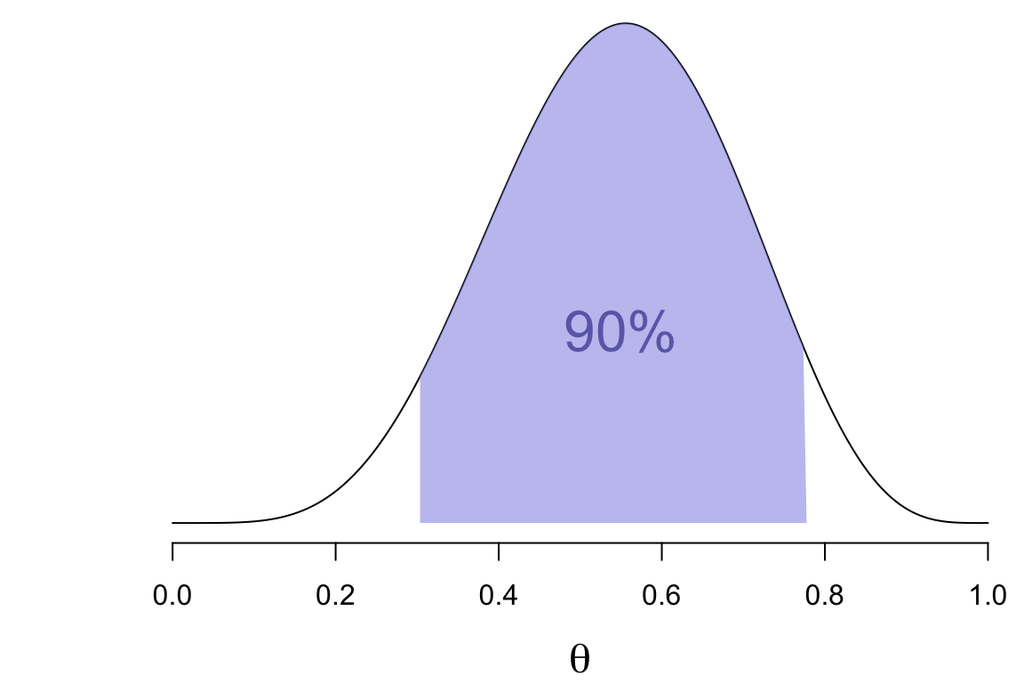

```r
a <- 2
b <- 3
n <- 6
y <- 4
L <- qbeta(0.05, a + y, b + n - y)
R <- qbeta(0.95, a + y, b + n - y)

col_post <- rgb(0.6, 0.6, 0.9, 0.6)
col_post_txt <- rgb(0.4, 0.4, 0.7, 0.95)

par(mar = c(4,4,0,0) + 0.1)
curve(dbeta(x, a + y, b + n - y), from = 0, to = 1, n = 1000,
      xlab = expression(theta), ylab = "", cex.lab = 1.5, axes = FALSE)
axis(side = 1)
x_coords <- c(L, seq(L, R, by = 0.01), R)
y_coords <- c(0, dbeta(seq(L, R, by = 0.01), a + y, b + n - y), 0)
polygon(x_coords, y_coords, col = col_post, border = "NA")

text(0.55, 1.0, expression("90%"), col = col_post_txt, cex = 2)
```

## Posterior predictive distributions

**Definition**

The **posterior predictive** distribution for $\tilde{x}$ is analogous to the prior predictive distribution, but it is derived from the posterior:

$$f(\tilde{x} \mid \boldsymbol{x}) = \int_\Theta f(\tilde{x} \mid \theta) \, \Pi(\mbox{d}\theta \mid \boldsymbol{x}) \, .$$

Sampling from the posterior predictive is straightforward: for each posterior sample of $\theta$, take a draw from the sampling model (or likelihood).

The posterior predictive distribution for future data can be transformed to make probabilistic statements on quantities derived from data.

## Posterior predictive distributions

**Dating example continued**

We have $\theta \mid \boldsymbol{x} \sim \mbox{Beta}(a + \sum_i x_i, \ b + n - \sum_i x_i)$.

Find the posterior predictive distribution for the outcome of a single effort $\tilde{x}$.

Generate draws from the posterior predictive distribution and compare.

## Posterior predictive distributions

**Plug-in estimates**

Note that $f(\tilde{x} \mid \boldsymbol{x}) = \int_\Theta f(\tilde{x} \mid \theta) \, \Pi(\mbox{d}\theta \mid \boldsymbol{x}) \ne f(\tilde{x} \mid \hat{\theta})$

where $\hat{\theta}$ is a point estimate of $\theta$, i.e., posterior mean.

Why? What is missing?

## Posterior predictive derived quantities

**Dating example continued**

Suppose that you will make three more efforts to show interest. If your date responds positively to at least two of them, you will invite them on a second date.

What is the probability (given the past data) that you will invite them on a second date?

**Challenge problem**: What then is the probability that you will get at least two positive responses AND that they will say yes (with probability $\theta$), given two or more positive responses?

[figure not shown]